# Test a Perceptual Phenomenon

### Analyzing the Stroop Effect

Statistics: The Science of Decisions Project Instructions

#### Background Information

In a Stroop task, participants are presented with a list of words, with each word displayed in a color of ink. The participant’s task is to say out loud the color of the ink in which the word is printed. The task has two conditions: a congruent words condition, and an incongruent words condition. In the congruent words condition, the words being displayed are color words whose names match the colors in which they are printed: for example RED, BLUE. In the incongruent words condition, the words displayed are color words whose names do not match the colors in which they are printed: for example PURPLE, ORANGE. In each case, we measure the time it takes to name the ink colors in equally-sized lists. Each participant will go through and record a time from each condition.

##### Questions For Investigation

As a general note, be sure to keep a record of any resources that you use or refer to in the creation of your project. You will need to report your sources as part of the project submission.

1. What is our independent variable? What is our dependent variable?
2. What is an appropriate set of hypotheses for this task? What kind of statistical test do you expect to perform? Justify your choices.
3. Report some descriptive statistics regarding this dataset. Include at least one measure of central tendency and at least one measure of variability.
4. Provide one or two visualizations that show the distribution of the sample data. Write one or two sentences noting what you observe about the plot or plots.
5. Now, perform the statistical test and report your results. What is your confidence level and your critical statistic value? Do you reject the null hypothesis or fail to reject it? Come to a conclusion in terms of the experiment task. Did the results match up with your expectations?

```python
# import the packages we need
import pandas as pd
import numpy as np
import math
import seaborn as sns
from scipy.stats import ttest_rel
from scipy import stats
%matplotlib inline
```

```python
# read the csv file
df_stroop = pd.read_csv('C:\\Users\\-\\Downloads\\stroopdata.csv')
df_stroop.head(30)
```

|  | Congruent | Incongruent |
| --- | --- | --- |
| 0 | 12.079 | 19.278 |
| 1 | 16.791 | 18.741 |
| 2 | 9.564 | 21.214 |
| 3 | 8.630 | 15.687 |
| 4 | 14.669 | 22.803 |
| 5 | 12.238 | 20.878 |
| 6 | 14.692 | 24.572 |
| 7 | 8.987 | 17.394 |
| 8 | 9.401 | 20.762 |
| 9 | 14.480 | 26.282 |
| 10 | 22.328 | 24.524 |
| 11 | 15.298 | 18.644 |
| 12 | 15.073 | 17.510 |
| 13 | 16.929 | 20.330 |
| 14 | 18.200 | 35.255 |
| 15 | 12.130 | 22.158 |
| 16 | 18.495 | 25.139 |
| 17 | 10.639 | 20.429 |
| 18 | 11.344 | 17.425 |
| 19 | 12.369 | 34.288 |
| 20 | 12.944 | 23.894 |
| 21 | 14.233 | 17.960 |
| 22 | 19.710 | 22.058 |
| 23 | 16.004 | 21.157 |

(1) What is the independent variable? What is the dependent variable?

**Independent variable:**

there is two independent variable:

- The `Congruent` words condition.
- The `Incongruent` words condition.

**Dependent variable:**  
the rection `Time` to complete the test.

(2) What is an appropriate set of hypotheses for this task? Specify your null and alternative hypotheses, and clearly define any notation used. Justify your choices.

We need to choose which statistical test to use, there are many different tests we can use in statistics.  
There are 3 questions we should ask :

**1- What level of measurement was used for the data we are analyzing ?**  
Our data are Interval/Ratio (contains) quantitative data.

**2- How many samples are involved ?**  
We have one sample of 24 subjects with two variables.

**3- What is the purpose of the analysis ?**  
Comparing two statistics.

And we cannot determine the population parameters.  
**From the information above the test is difference of two means, paired sample (Paired Sample T-Test)**

based on this question we will write our hypotheses: **Are the population means different?**  
We want to see if there is a significant difference between two values.

The null hypotheses **$H_{0}$** : There is no significant difference between the population mean of congruent values and population mean of incongruent values.  
The alternative hypotheses **$H_{1}$** : There is significant difference between the population mean of congruent values and population mean of incongruent values.

where $μ_{C}$ is the population mean of congruent values.  
and $μ_{I}$ is the population mean of incongruent values.

(3) Report some descriptive statistics regarding this dataset. Include at least one measure of central tendency and at least one measure of variability. The name of the data file is 'stroopdata.csv'.

Measure of central tendency

```python
df_stroop.describe()
```

|  | Congruent | Incongruent |
| --- | --- | --- |
| count | 24.000000 | 24.000000 |
| mean | 14.051125 | 22.015917 |
| std | 3.559358 | 4.797057 |
| min | 8.630000 | 15.687000 |
| 25% | 11.895250 | 18.716750 |
| 50% | 14.356500 | 21.017500 |
| 75% | 16.200750 | 24.051500 |
| max | 22.328000 | 35.255000 |

```python
df_stroop.count()
```

```
Congruent      24
Incongruent    24
dtype: int64
```

```python
df_stroop.shape[0]
```

```
24
```

Measure of variability

```python
# calculate the Variance
c_var = df_stroop['Congruent'].var()
i_var = df_stroop['Incongruent'].var()
c_var, i_var
```

```
(12.669029070652174, 23.011757036231884)
```

```python
# calculate the Inter quartile range
c_iqr = df_stroop['Congruent'].quantile()
i_iqr = df_stroop['Incongruent'].quantile()
c_iqr, i_iqr
```

```
(14.3565, 21.0175)
```

As expected, the mean reaction time for the Congruent `14.05`s is lower than Incongruent `22.01`s. And we don't have any missing values on the test variables.

(4) Provide one or two visualizations that show the distribution of the sample data. Write one or two sentences noting what you observe about the plot or plots.

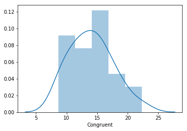

```python
sns.distplot(df_stroop['Congruent']);
```

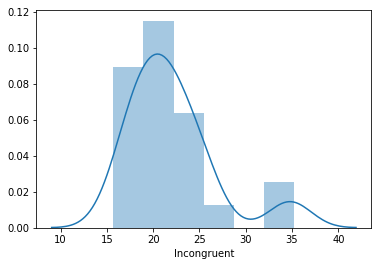

```python
sns.distplot(df_stroop['Incongruent']);
```

(5) Now, perform the statistical test and report your results. What is your confidence level or Type I error associated with your test? What is your conclusion regarding the hypotheses you set up? Did the results match up with your expectations? **Hint:** Think about what is being measured on each individual, and what statistic best captures how an individual reacts in each environment.

```python
# degrees of freedom
df = df_stroop['Congruent'].shape[0] -1
df
```

```
23
```

The critical value of `2.0687` using the [students-t-distribution-table](http://statcalculators.com/students-t-distribution-table/) for a two-tailed test with `23` degrees of freedom and an alpha of `0.05`.

The confidence level is `95%`.

The value of t-critical is $t_{critica}=±$ `2.0687` , decision rule is rejecting the null hypothesis if t-statistic value is less than `-2.0687` or greater than `2.0687`.

```python
# find the diffenence of Incongruent and congruent reaction time
df_stroop['difference'] = df_stroop['Congruent'] - df_stroop['Incongruent']
df_stroop
```

|  | Congruent | Incongruent | difference |
| --- | --- | --- | --- |
| 0 | 12.079 | 19.278 | -7.199 |
| 1 | 16.791 | 18.741 | -1.950 |
| 2 | 9.564 | 21.214 | -11.650 |
| 3 | 8.630 | 15.687 | -7.057 |
| 4 | 14.669 | 22.803 | -8.134 |
| 5 | 12.238 | 20.878 | -8.640 |
| 6 | 14.692 | 24.572 | -9.880 |
| 7 | 8.987 | 17.394 | -8.407 |
| 8 | 9.401 | 20.762 | -11.361 |
| 9 | 14.480 | 26.282 | -11.802 |
| 10 | 22.328 | 24.524 | -2.196 |
| 11 | 15.298 | 18.644 | -3.346 |
| 12 | 15.073 | 17.510 | -2.437 |
| 13 | 16.929 | 20.330 | -3.401 |
| 14 | 18.200 | 35.255 | -17.055 |
| 15 | 12.130 | 22.158 | -10.028 |
| 16 | 18.495 | 25.139 | -6.644 |
| 17 | 10.639 | 20.429 | -9.790 |
| 18 | 11.344 | 17.425 | -6.081 |
| 19 | 12.369 | 34.288 | -21.919 |
| 20 | 12.944 | 23.894 | -10.950 |
| 21 | 14.233 | 17.960 | -3.727 |
| 22 | 19.710 | 22.058 | -2.348 |
| 23 | 16.004 | 21.157 | -5.153 |

```python
# Calculate the Mean for the difference
d_mean = df_stroop['difference'].mean()
d_mean
```

```
-7.964791666666667
```

```python
# Calculate the Standerd Deviation for the difference
d_std = df_stroop['difference'].std()
d_std
```

```
4.864826910359056
```

Confidance Interval = `(-10.01937, -5.910215)`,That's mean on average the participants will take `5.910215` to `10.01937` seconds more when presented with an incongruent data set as opposed to when presented with a congruent data set.

```python
# Calculate the t-value and p-value using the t-test
ttest_pair = ttest_rel(df_stroop['Congruent'] , df_stroop['Incongruent'])
ttest_pair
```

```
Ttest_relResult(statistic=-8.020706944109957, pvalue=4.103000585711178e-08)
```

- The absolute value of test statistic `8.020706` is greater than the critical value`2.0687`.
- The p value `4.103e-08` is lower than alpha `0.05`.

From the above we can declare statistical significance and **reject the null hypothesis**, Which mean that the difference between reaction time of congruence and incongruence is statistically significant.  
Participants do not name the colors at the same speed when the color and words don't match, Which matches up with what we expected.

## Resources

https://www.thoughtco.com/independent-and-dependent-variables-differences-606115  
https://www.statisticssolutions.com/manova-analysis-one-sample-t-test/  
https://statistics.laerd.com/statistical-guides/independent-t-test-statistical-guide.php  
https://www.statisticssolutions.com/should-you-use-a-one-tailed-test-or-a-two-tailed-test-for-your-data-analysis/  
https://docs.scipy.org/doc/scipy-0.15.1/reference/generated/scipy.stats.ttest_ind.html  
https://www.statisticssolutions.com/manova-analysis-paired-sample-t-test/  
https://sciencing.com/use-onesample-paired-unpaired-ttest-4782861.html  
https://www.investopedia.com/terms/t/t-test.asp  
https://www.youtube.com/watch?v=uwTYD60nng4  
https://www.youtube.com/watch?v=rulIUAN0U3w  
https://www.marsja.se/pandas-python-descriptive-statistics/  
https://seaborn.pydata.org/generated/seaborn.distplot.html  
https://pythonfordatascience.org/paired-samples-t-test-python/  
https://support.minitab.com/en-us/minitab-express/1/help-and-how-to/basic-statistics/inference/supporting-topics/basics/what-is-a-critical-value/